## In-class worksheet 11

**Feb 20, 2018**

In this worksheet, we will use the library tidyverse and ggthemes (for colorblind-friendly color scale `scale_color_colorblind()`):

```r
library(tidyverse)
theme_set(theme_bw(base_size=12)) # set default ggplot2 theme
# install.packages("ggthemes")
library(ggthemes)
```

# 1. Fitting a logistic regression model to the iris data set

We will work with the `iris` data set. Specifically, with a subset of the data that consists only of the species virginica and versicolor:

```r
# make a reduced iris data set that only contains virginica and versicolor species
iris.small <- filter(iris, Species %in% c("virginica", "versicolor"))
head(iris.small)
```

```
##   Sepal.Length Sepal.Width Petal.Length Petal.Width    Species
## 1          7.0         3.2          4.7         1.4 versicolor
## 2          6.4         3.2          4.5         1.5 versicolor
## 3          6.9         3.1          4.9         1.5 versicolor
## 4          5.5         2.3          4.0         1.3 versicolor
## 5          6.5         2.8          4.6         1.5 versicolor
## 6          5.7         2.8          4.5         1.3 versicolor
```

Fit a logistic regression model to the `iris.small` data set. Then successively remove predictors until only predictors with a p value less than 0.1 remain.

```r
glm.out <- glm(Species ~ Sepal.Length + Sepal.Width + Petal.Length + Petal.Width,
               data = iris.small,
               family = binomial)
summary(glm.out)
```

```
##
## Call:
## glm(formula = Species ~ Sepal.Length + Sepal.Width + Petal.Length +
##     Petal.Width, family = binomial, data = iris.small)
##
## Deviance Residuals:
##      Min        1Q    Median        3Q       Max
## -2.01105  -0.00541  -0.00001   0.00677   1.78065
##
## Coefficients:
##              Estimate Std. Error z value Pr(>|z|)
## (Intercept)   -42.638     25.707  -1.659   0.0972 .
## Sepal.Length   -2.465      2.394  -1.030   0.3032
## Sepal.Width    -6.681      4.480  -1.491   0.1359
## Petal.Length    9.429      4.737   1.991   0.0465 *
## Petal.Width    18.286      9.743   1.877   0.0605 .
## ---
## Signif. codes:  0 '***' 0.001 '**' 0.01 '*' 0.05 '.' 0.1 ' ' 1
##
## (Dispersion parameter for binomial family taken to be 1)
##
##     Null deviance: 138.629  on 99  degrees of freedom
## Residual deviance:  11.899  on 95  degrees of freedom
## AIC: 21.899
##
## Number of Fisher Scoring iterations: 10
```

```r
# Remove Sepal.Length because its p-value is 0.30
glm.out <- glm(Species ~ Sepal.Width + Petal.Length + Petal.Width,
               data = iris.small,
               family = binomial)
summary(glm.out)
```

```
##
## Call:
## glm(formula = Species ~ Sepal.Width + Petal.Length + Petal.Width,
##     family = binomial, data = iris.small)
##
## Deviance Residuals:
##      Min        1Q    Median        3Q       Max
## -1.75795  -0.00412   0.00000   0.00290   1.92193
##
## Coefficients:
##              Estimate Std. Error z value Pr(>|z|)
## (Intercept)   -50.527     23.995  -2.106   0.0352 *
## Sepal.Width    -8.376      4.761  -1.759   0.0785 .
## Petal.Length    7.875      3.841   2.050   0.0403 *
## Petal.Width    21.430     10.707   2.001   0.0453 *
## ---
## Signif. codes:  0 '***' 0.001 '**' 0.01 '*' 0.05 '.' 0.1 ' ' 1
##
## (Dispersion parameter for binomial family taken to be 1)
##
##     Null deviance: 138.629  on 99  degrees of freedom
## Residual deviance:  13.266  on 96  degrees of freedom
## AIC: 21.266
##
## Number of Fisher Scoring iterations: 10
```

Make a plot of the fitted probability as a function of the linear predictor, colored by species identity. Hint: you will have to make a new data frame combining data from the fitted model with data from the `iris.small` data frame.

```r
iris.predicted <- data.frame(iris.small,prob = glm.out$fitted.values,predictor = glm.out$linear.predictors)
head(iris.predicted)
```

```
##   Sepal.Length Sepal.Width Petal.Length Petal.Width    Species
## 1          7.0         3.2          4.7         1.4 versicolor
## 2          6.4         3.2          4.5         1.5 versicolor
## 3          6.9         3.1          4.9         1.5 versicolor
## 4          5.5         2.3          4.0         1.3 versicolor
## 5          6.5         2.8          4.6         1.5 versicolor
## 6          5.7         2.8          4.5         1.3 versicolor
##           prob  predictor
## 1 3.301684e-05 -10.318460
## 2 5.826738e-05  -9.750410
## 3 3.131883e-03  -5.762984
## 4 2.938084e-05 -10.435139
## 5 3.638542e-03  -5.612527
## 6 2.286455e-05 -10.685900
```

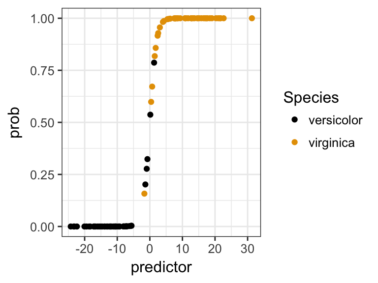

```r
iris.predicted %>% ggplot(aes(x = predictor, y = prob, color=Species)) +
  geom_point() +
  scale_color_colorblind()
```

```r
# plot the line
virg_data <- filter(iris.predicted, Species=='virginica')
vers_data <- filter(iris.predicted, Species=='versicolor')
```

Make a density plot that shows how the two species are separated by the linear predictor.

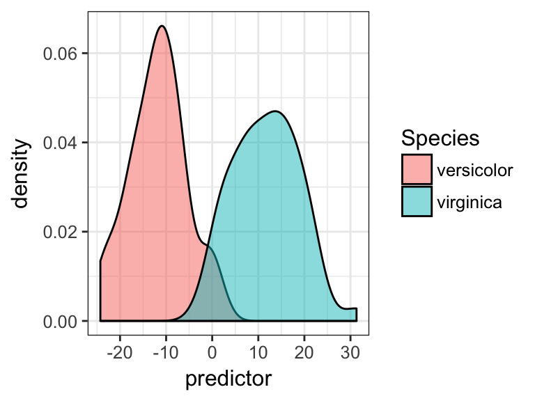

```r
iris.predicted %>% ggplot(aes(x = predictor, fill=Species)) +
  geom_density(alpha=.5) +
  scale_color_colorblind() #? color different?
```

# 2. Predicting the species

Assume you have obtained samples from three plants, with measurements as listed below. Predict the likelihood that each of these plants belongs to the species virginica.

```r
plant1 <- data.frame(Sepal.Length=6.4, Sepal.Width=2.8, Petal.Length=4.6, Petal.Width=1.8)
plant2 <- data.frame(Sepal.Length=6.3, Sepal.Width=2.5, Petal.Length=4.1, Petal.Width=1.7)
plant3 <- data.frame(Sepal.Length=6.7, Sepal.Width=3.3, Petal.Length=5.2, Petal.Width=2.3)
```

```r
predict(glm.out,plant1, type = 'response')
```

```
##         1
## 0.6934611
```

```r
predict(glm.out,plant2, type = 'response')
```

```
##          1
## 0.06002675
```

```r
predict(glm.out,plant3, type = 'response')
```

```
##         1
## 0.9999943
```

# 3. If this was easy

Pick a cutoff predictor value at which you would decide that a specimen belongs to virginica rather than versicolor. Calculate how many virginicas you call correctly and how many incorrectly given that choice.

```r
# how to pick the best cutoff predictor value? 0 seems good!
iris.predicted %>% filter(Species=='virginica' & predictor > 0) %>%
  select(prob) %>%
  summarize(correct_virginica=n())
```

```
##   correct_virginica
## 1                49
```

```r
iris.predicted %>% filter(Species=='virginica') %>%
  summarize(total_virginica=n())
```

```
##   total_virginica
## 1              50
```

Now do the same calculation for versicolor.

```r
iris.predicted %>% filter(Species=='versicolor' & predictor < 0) %>%
  select(prob) %>%
  summarize(correct_versicolor=n())
```

```
##   correct_versicolor
## 1                 48
```

```r
iris.predicted %>% filter(Species=='versicolor') %>%
  summarize(total_versicolor=n())
```

```
##   total_versicolor
## 1               50
```

If we define a call of virginica as a positive and a call of versicolor as a negative, what are the true positive rate (sensitivity, true positives divided by all possible positives) and the true negative rate (specificity, true negatives divided by all possible negatives) in your analysis?

```r
# true positive rate
(49)/50*100
```

```
## [1] 98
```

```r
# true negative rate
(48)/50*100
```

```
## [1] 96
```